# FML64060_ASSIGNMENT_1

NIHARIKA MATSA

2023-09-09

## Dataset reference

I have downloaded the dataset from Kaggle which has both qualitative and quantitative data. Please find the dataset below - https://www.kaggle.com/datasets/pyatakov/india-agriculture-crop-production

## using readxl package

As our dataset is in excel format, we need to use the library called “readxl” so that we can load our dataset.

```r
library(readxl)
library(knitr)
```

## Import the dataset

```r
agri_data <- read_excel("India Agriculture Crop Production.xlsx")
agri_data_df <- data.frame(agri_data)
```

## Display the data

```r
### I just want to display all the columns in the dataset. Hence using options().
options(tibble.width = Inf)

### In order to display the data in a table format, I have used kable.
kable(head(agri_data_df), format = "markdown")
```

| State | District | Crop | Year | Season | Area | Area.Units | Production | Production.Units | Yield |
| --- | --- | --- | --- | --- | --- | --- | --- | --- | --- |
| Andaman and Nicobar Islands | NICOBARS | Arecanut | 2001-02 | Kharif | 1254 | Hectare | 2061 | Tonnes | 1.643541 |
| Andaman and Nicobar Islands | NICOBARS | Arecanut | 2002-03 | Whole Year | 1258 | Hectare | 2083 | Tonnes | 1.655803 |
| Andaman and Nicobar Islands | NICOBARS | Arecanut | 2003-04 | Whole Year | 1261 | Hectare | 1525 | Tonnes | 1.209358 |
| Andaman and Nicobar Islands | NORTH AND MIDDLE ANDAMAN | Arecanut | 2001-02 | Kharif | 3100 | Hectare | 5239 | Tonnes | 1.690000 |
| Andaman and Nicobar Islands | SOUTH ANDAMANS | Arecanut | 2002-03 | Whole Year | 3105 | Hectare | 5267 | Tonnes | 1.696296 |
| Andaman and Nicobar Islands | SOUTH ANDAMANS | Arecanut | 2003-04 | Whole Year | 3118 | Hectare | 5182 | Tonnes | 1.661963 |

## Summary of the data

Summary displays the class and mode of each column if it is a qualitative data and it displays the min, max, mean, median, etc., if it is a quantitative data.

```r
summary(agri_data_df)
```

```
##     State             District             Crop               Year
##  Length:345407      Length:345407      Length:345407      Length:345407
##  Class :character   Class :character   Class :character   Class :character
##  Mode  :character   Mode  :character   Mode  :character   Mode  :character
##
##
##
##
##     Season               Area          Area.Units          Production
##  Length:345407      Min.   :      0   Length:345407      Min.   :0.000e+00
##  Class :character   1st Qu.:     74   Class :character   1st Qu.:8.700e+01
##  Mode  :character   Median :    532   Mode  :character   Median :7.170e+02
##                     Mean   :  11670                      Mean   :9.584e+05
##                     3rd Qu.:   4110                      3rd Qu.:7.176e+03
##                     Max.   :8580100                      Max.   :1.598e+09
##                     NA's   :33                           NA's   :4993
##  Production.Units       Yield
##  Length:345407      Min.   :    0.00
##  Class :character   1st Qu.:    0.55
##  Mode  :character   Median :    1.00
##                     Mean   :   79.41
##                     3rd Qu.:    2.47
##                     Max.   :43958.33
##                     NA's   :33
```

## Descriptive Statistics for the quantitative data from the dataset

### Calculate Mean

Add all the values from column and divide it by total number of values.

```r
### I see that there are few missing values in the Area, Yield and Production column.
colMeans(agri_data_df[,c('Area', 'Production','Yield')],na.rm = TRUE)
```

```
##         Area   Production        Yield
##  11670.19126 958371.14866     79.40757
```

### Calculate Median

To find the median, first arrange the values in the ascending order and then pick the middle number. a. If the total count is odd then we can have one median value (i.e., Middle number) b. If the total count is even then we will have two middle numbers, in order to find median for them, we have to calculate mean for those two numbers and the result will be our median.

```r
median(agri_data_df$Area, na.rm = TRUE)
```

```
## [1] 532
```

```r
median(agri_data_df$Production, na.rm = TRUE)
```

```
## [1] 717
```

```r
median(agri_data_df$Yield, na.rm = TRUE)
```

```
## [1] 1
```

### Calculate Min value for Area, Production and Yield

```r
min(agri_data_df$Area, na.rm = TRUE)
```

```
## [1] 0.004
```

```r
min(agri_data_df$Production, na.rm = TRUE)
```

```
## [1] 0
```

```r
min(agri_data_df$Yield, na.rm = TRUE)
```

```
## [1] 0
```

### Calculate Max value for Area, Production and Yield

```r
max(agri_data_df$Area, na.rm = TRUE)
```

```
## [1] 8580100
```

```r
max(agri_data_df$Production, na.rm =TRUE)
```

```
## [1] 1597800000
```

```r
max(agri_data_df$Yield, na.rm = TRUE)
```

```
## [1] 43958.33
```

## Descriptive Statistics for the qualitative data from the dataset

### Calculate Mode

To find mode, first arrange the values in the ascending order and find the response which occurs most frequently. Dataset can have no mode, one mode or more than one mode.

```r
### Calculate the mode for State
mode_result <- as.data.frame(sort(table(agri_data_df$State), decreasing = TRUE))

### Rename columns for clarity
colnames(mode_result) <- c("State", "Mode")

### Display the result in table format
kable(mode_result, format = "markdown")
```

| State | Mode |
| --- | --- |
| Uttar Pradesh | 44781 |
| Madhya Pradesh | 29906 |
| Karnataka | 27493 |
| Bihar | 24697 |
| Rajasthan | 20363 |
| Tamil Nadu | 18525 |
| Assam | 18186 |
| Maharashtra | 17922 |
| Andhra Pradesh | 16363 |
| Odisha | 16153 |
| Chhattisgarh | 15285 |
| Gujarat | 14053 |
| West Bengal | 12596 |
| Haryana | 8305 |
| Uttarakhand | 6702 |
| Nagaland | 5676 |
| Himachal Pradesh | 5043 |
| Jharkhand | 5004 |
| Kerala | 4870 |
| Telangana | 4704 |
| Jammu and Kashmir | 4348 |
| Arunachal Pradesh | 4345 |
| Meghalaya | 4322 |
| Punjab | 4142 |
| Manipur | 3120 |
| Tripura | 2557 |
| Mizoram | 2112 |
| Puducherry | 1127 |
| Sikkim | 876 |
| Andaman and Nicobar Islands | 728 |
| Goa | 399 |
| Dadra and Nagar Haveli | 332 |
| Delhi | 203 |
| Chandigarh | 124 |
| Daman and Diu | 44 |
| Laddakh | 1 |

```r
### Calculate the mode for Season
season_result <- as.data.frame(sort(table(agri_data_df$Season), decreasing = TRUE))

### Rename columns for clarity
colnames(season_result) <- c("Season", "Mode")

### Display the result in table format
kable(season_result, format = "markdown")
```

| Season | Mode |
| --- | --- |
| Kharif | 138400 |
| Rabi | 100977 |
| Whole Year | 68689 |
| Summer | 22101 |
| Winter | 8250 |
| Autumn | 6989 |
| nan | 1 |

```r
### Calculate the mode for Crop
crop_result <- as.data.frame(sort(table(agri_data_df$Crop), decreasing = TRUE))

### Rename columns for clarity
colnames(crop_result) <- c("Crop", "Mode")

### Display the result in table format
kable(crop_result, format = "markdown")
```

| Crop | Mode |
| --- | --- |
| Rice | 21611 |
| Maize | 20507 |
| Moong(Green Gram) | 15101 |
| Urad | 14581 |
| Sesamum | 13049 |
| Groundnut | 12586 |
| Wheat | 11248 |
| Rapeseed &Mustard | 11034 |
| Sugarcane | 10942 |
| Arhar/Tur | 10895 |
| Potato | 10756 |
| Onion | 10675 |
| Gram | 10474 |
| Jowar | 9769 |
| Dry chillies | 8971 |
| Bajra | 7796 |
| Peas & beans (Pulses) | 7266 |
| Sunflower | 7244 |
| Small millets | 6985 |
| Cotton(lint) | 6475 |
| Masoor | 6383 |
| Turmeric | 5953 |
| Linseed | 5892 |
| Barley | 5891 |
| Ragi | 5757 |
| Sweet potato | 5742 |
| Other Kharif pulses | 5720 |
| Horse-gram | 5424 |
| Coriander | 5037 |
| Garlic | 5032 |
| Soyabean | 4988 |
| Other Rabi pulses | 4866 |
| Ginger | 4686 |
| Castor seed | 4681 |
| Banana | 4509 |
| Tobacco | 3590 |
| Sannhamp | 3017 |
| Coconut | 2927 |
| Niger seed | 2792 |
| Mesta | 2406 |
| Tapioca | 2268 |
| Arecanut | 2192 |
| Guar seed | 2088 |
| Jute | 1913 |
| Safflower | 1764 |
| Cowpea(Lobia) | 1761 |
| Khesari | 1759 |
| Cashewnut | 1573 |
| Black pepper | 1417 |
| Moth | 1408 |
| Other Cereals | 1387 |
| other oilseeds | 1240 |
| Oilseeds total | 702 |
| Cardamom | 575 |
| Other Summer Pulses | 67 |
| Dry Ginger | 3 |

## Transform atleast one variable

```r
### We need dplyr library to rename the column name
library(dplyr)
### Rename the columns
agri_data_df <- agri_data_df %>%
  rename(
    Production_Units = Production.Units,
    Area_Units = Area.Units
  )

### We are converting Hectares to Kilometers for Area_Units column
agri_data_df <- agri_data_df %>%
  mutate(
    Area = Area/100
  )

### Displays the number of rows in the dataset
nrow(agri_data_df)
```

```
## [1] 345407
```

```r
### Assigning the Area Units value as Kilometers as we have converted Hectare to Kilometers
agri_data_df$Area_Units <- 'Kilometers'

### Round off the values for Area, Production and Yield
agri_data_df$Yield <- round(agri_data_df$Yield, digits=2)
agri_data_df$Production <- round(agri_data_df$Production, digits=2)
agri_data_df$Area <- round(agri_data_df$Area, digits=2)
```

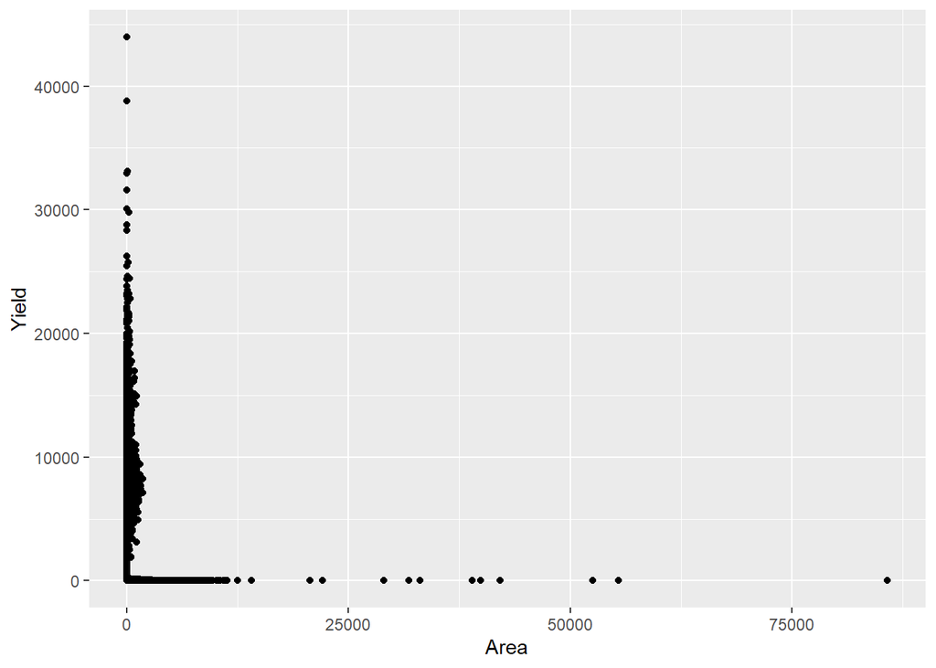

```r
#### Load the ggplot2 package
library(ggplot2)
# Create a scatter plot
scatter_plot <- ggplot(agri_data_df, aes(x = Area, y = Yield)) +
  geom_point()

# Display the scatter plot
print(scatter_plot)
```

### Bar Plot for Year and Yield

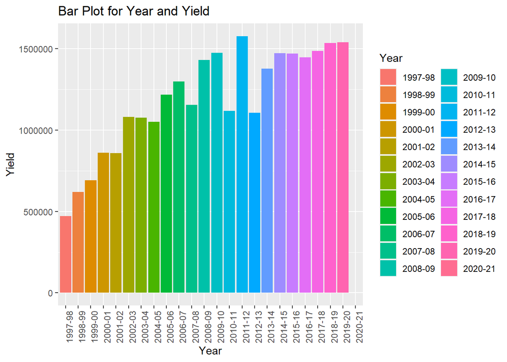

```r
# Create a bar plot
colors <- c("red","green", "blue","purple", "orange")
ggplot(agri_data_df, aes(x = Year, y = Yield, fill= Year)) +
  geom_bar(stat = "identity") +
  labs(title = "Bar Plot for Year and Yield") +
  theme(axis.text.x = element_text(angle = 90, hjust = 1))
```